# Machine Learning

Akshay Goyal

13/01/2022

### Importing libraries and setting working directory

```r
library(dplyr)
library(readr)
library(ggplot2)
library(pwr)
library(EnvStats)
library(reshape2)
library(PMCMR)
library(readxl)
```

### Exploring the data.

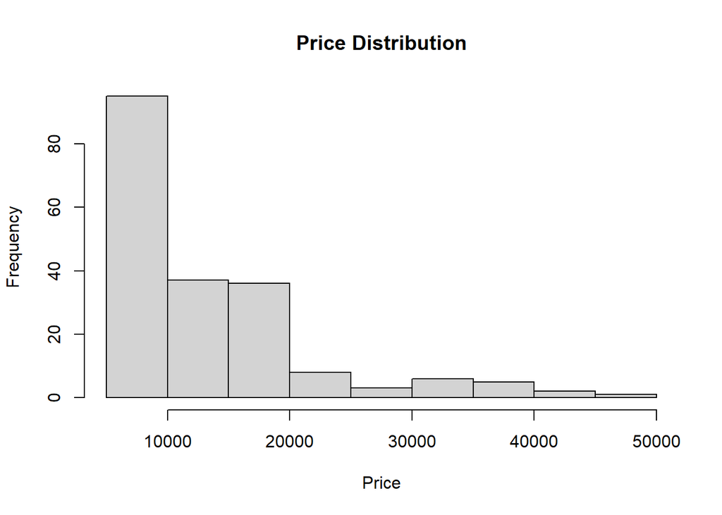

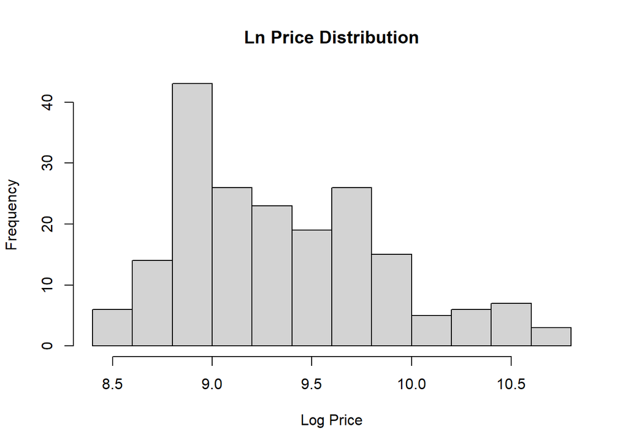

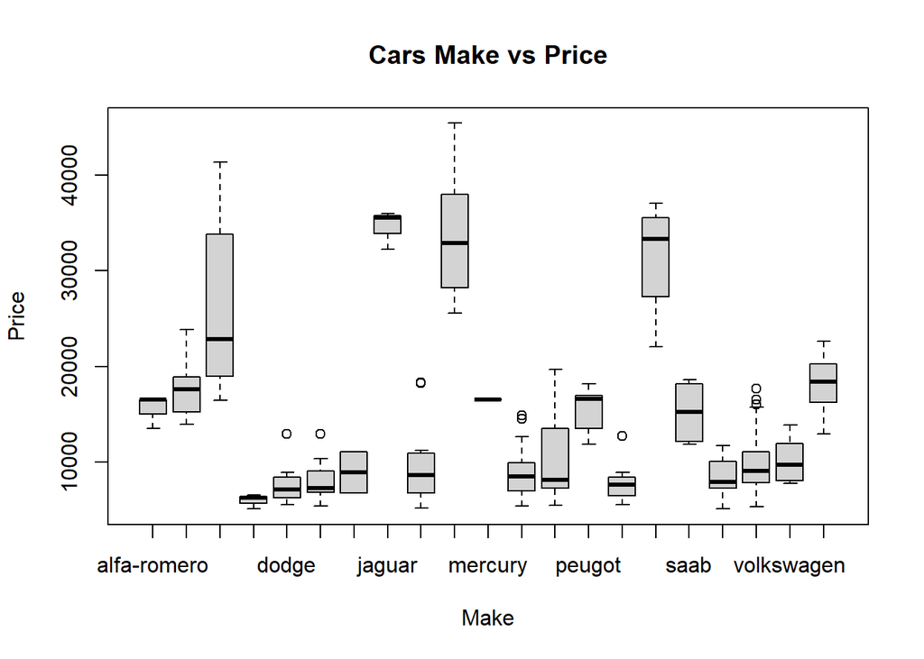

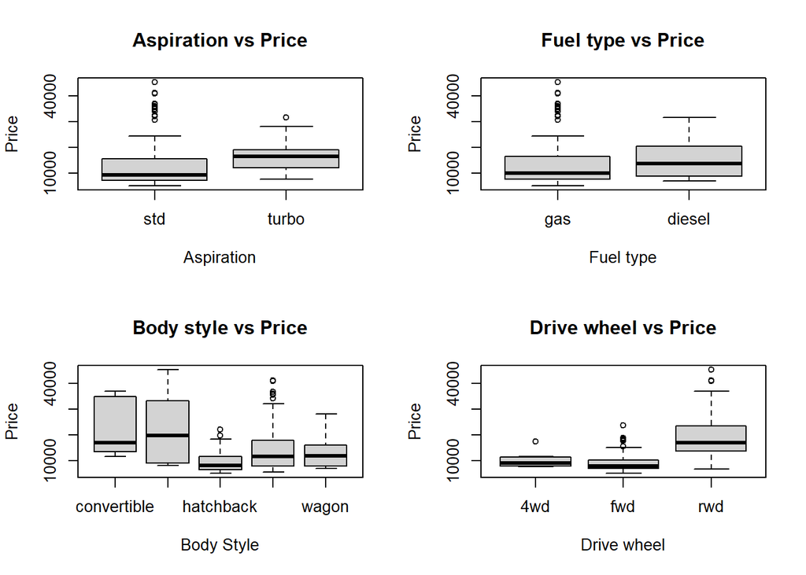

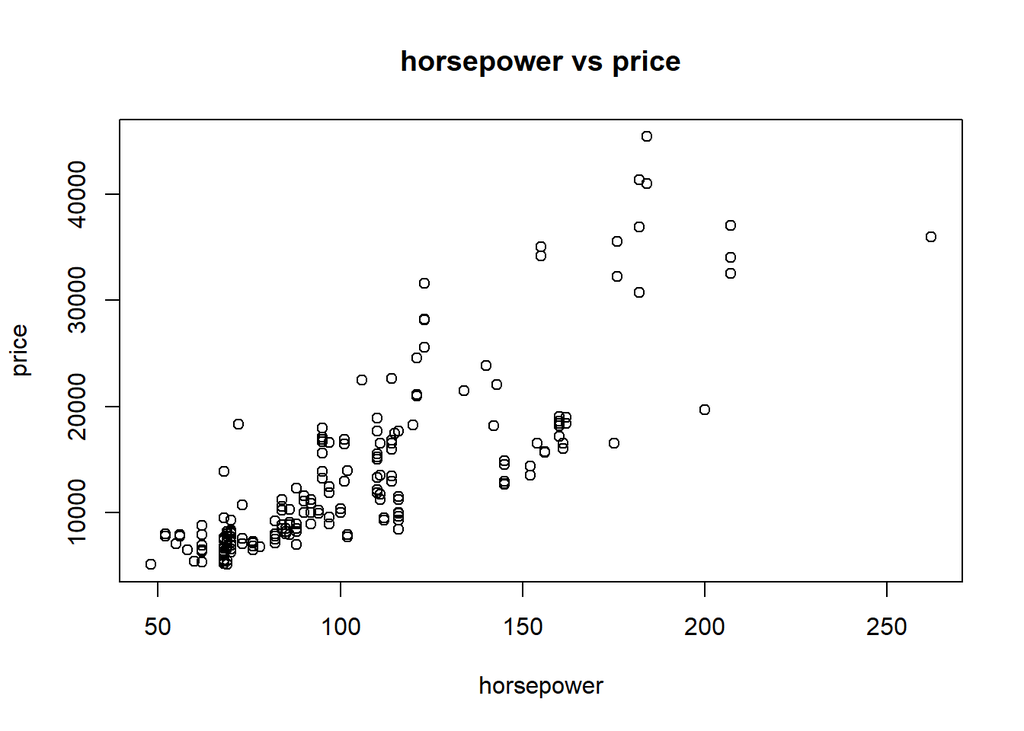

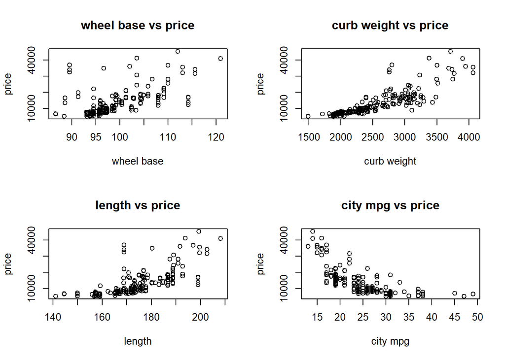

```
## [1] "Correlation Matrix:"
##                   wheel_base length width height curb_weight  bore stroke
## wheel_base              1.00   0.88  0.82   0.59        0.78  0.50   0.17
## length                  0.88   1.00  0.86   0.49        0.88  0.61   0.12
## width                   0.82   0.86  1.00   0.31        0.87  0.54   0.19
## height                  0.59   0.49  0.31   1.00        0.31  0.18  -0.05
## curb_weight             0.78   0.88  0.87   0.31        1.00  0.65   0.18
## bore                    0.50   0.61  0.54   0.18        0.65  1.00  -0.07
## stroke                  0.17   0.12  0.19  -0.05        0.18 -0.07   1.00
## compression_ratio       0.25   0.16  0.19   0.25        0.16  0.00   0.20
## horsepower              0.38   0.59  0.62  -0.08        0.76  0.57   0.10
## peak_rpm               -0.35  -0.28 -0.25  -0.26       -0.28 -0.27  -0.07
## city_mpg               -0.50  -0.70 -0.66  -0.11       -0.78 -0.60  -0.03
## highway_mpg            -0.57  -0.73 -0.70  -0.16       -0.82 -0.61  -0.04
##                   compression_ratio horsepower peak_rpm city_mpg highway_mpg
## wheel_base                     0.25       0.38    -0.35    -0.50       -0.57
## length                         0.16       0.59    -0.28    -0.70       -0.73
## width                          0.19       0.62    -0.25    -0.66       -0.70
## height                         0.25      -0.08    -0.26    -0.11       -0.16
## curb_weight                    0.16       0.76    -0.28    -0.78       -0.82
## bore                           0.00       0.57    -0.27    -0.60       -0.61
## stroke                         0.20       0.10    -0.07    -0.03       -0.04
## compression_ratio              1.00      -0.20    -0.44     0.31        0.25
## horsepower                    -0.20       1.00     0.10    -0.83       -0.81
## peak_rpm                      -0.44       0.10     1.00    -0.06       -0.01
## city_mpg                       0.31      -0.83    -0.06     1.00        0.97
## highway_mpg                    0.25      -0.81    -0.01     0.97        1.00
##
## n= 193
##
##
## P
##                   wheel_base length width  height curb_weight bore   stroke
## wheel_base                   0.0000 0.0000 0.0000 0.0000      0.0000 0.0154
## length            0.0000            0.0000 0.0000 0.0000      0.0000 0.0913
## width             0.0000     0.0000        0.0000 0.0000      0.0000 0.0086
## height            0.0000     0.0000 0.0000        0.0000      0.0111 0.4529
## curb_weight       0.0000     0.0000 0.0000 0.0000             0.0000 0.0147
## bore              0.0000     0.0000 0.0000 0.0111 0.0000             0.3689
## stroke            0.0154     0.0913 0.0086 0.4529 0.0147      0.3689
## compression_ratio 0.0004     0.0302 0.0086 0.0004 0.0253      0.9541 0.0054
## horsepower        0.0000     0.0000 0.0000 0.2585 0.0000      0.0000 0.1544
## peak_rpm          0.0000     0.0001 0.0005 0.0003 0.0000      0.0001 0.3444
## city_mpg          0.0000     0.0000 0.0000 0.1238 0.0000      0.0000 0.6662
## highway_mpg       0.0000     0.0000 0.0000 0.0264 0.0000      0.0000 0.5781
##                   compression_ratio horsepower peak_rpm city_mpg highway_mpg
## wheel_base        0.0004            0.0000     0.0000   0.0000   0.0000
## length            0.0302            0.0000     0.0001   0.0000   0.0000
## width             0.0086            0.0000     0.0005   0.0000   0.0000
## height            0.0004            0.2585     0.0003   0.1238   0.0264
## curb_weight       0.0253            0.0000     0.0000   0.0000   0.0000
## bore              0.9541            0.0000     0.0001   0.0000   0.0000
## stroke            0.0054            0.1544     0.3444   0.6662   0.5781
## compression_ratio                   0.0045     0.0000   0.0000   0.0005
## horsepower        0.0045                       0.1606   0.0000   0.0000
## peak_rpm          0.0000            0.1606              0.3991   0.9076
## city_mpg          0.0000            0.0000     0.3991            0.0000
## highway_mpg       0.0005            0.0000     0.9076   0.0000
```

Findings :

Categorical Variables:  
We see that there are primarily three segments of price targeted by different makes of the car. Some are premium, some deal in the middle range and some focus on lower price range cars.  
Turbo cars are generally more expensive.  
Hatchbacks are the lowest price cars and rear wheel drive are on the higher price range.

Numerical Variables:  
Horsepower and city_mpg,highway_mpg are highly negatively correlated.  
Length width are positively correlated with length of the car.

Price of the car increases as horsepower increases.  
Price of the car is also positively related to wheel base, length and weight of car.  
As city mpg of the car increases, price decreases as evident from the graph.

### Building linear regression model using the initial set of variables.

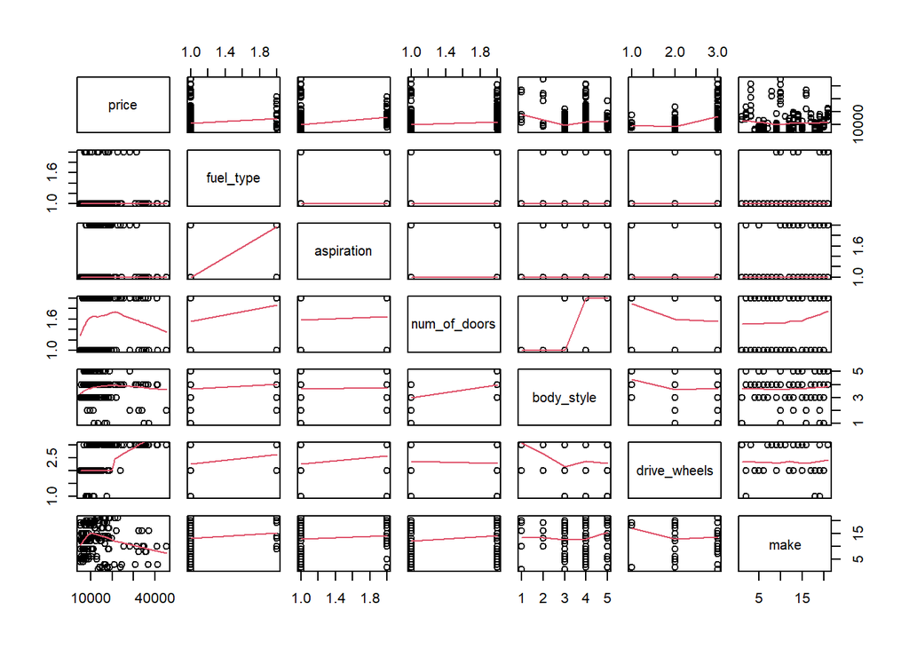

```r
#select data for initial linear model
data1 <- cars[ , c("price", "horsepower", "fuel_type", "aspiration", "num_of_doors",
                        "body_style", "drive_wheels", "make", "city_mpg", "length")]

# variables
price <- data1$price
hp <- data1$horsepower
ft <- data1$fuel_type
asp <- data1$aspiration
nod <- data1$num_of_doors
bs <- data1$body_style
dw <- data1$drive_wheels
make <- data1$make
cm <- data1$city_mpg
len <- data1$length

# plot relation between categorical fields and price
pairs(data1[,c(1,3:8)], panel = panel.smooth)
```

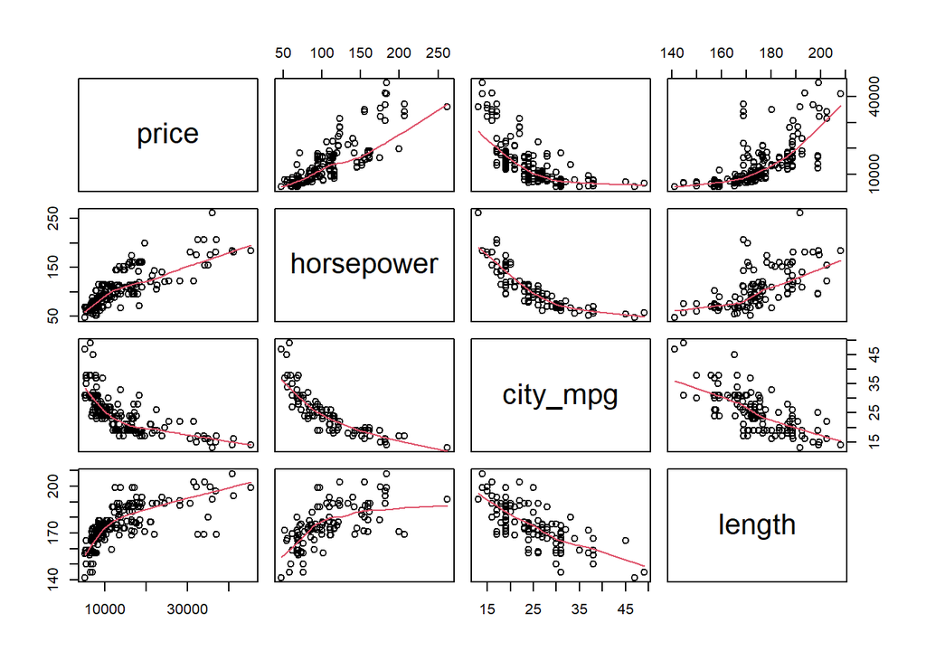

```r
# plot relation between numerical fields and price
pairs(data1[,c(1,2,9,10)], panel = panel.smooth)
```

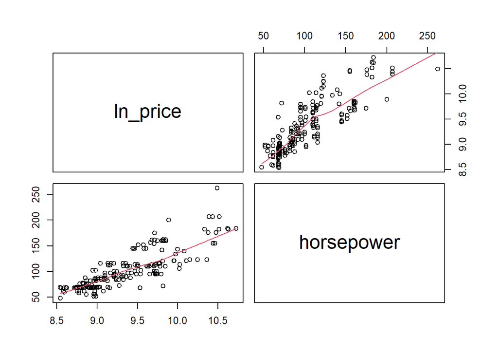

```r
# As we can see from the scatter plots, relationship between price and horsepower is almost linear.
# Where as, relationship between price and city_mpg, length is not linear. So we need to apply some transformation to make relationship more linear.
# we will choose to apply log transformation to price.
# to maintain linear relationship between price and hp, we will apply log transformation to horsepower also.

# transforming the variables
# log and inverse transformations
ln_price <- log(price)
in_price <- 1/price
ln_cm <- log(cm)
ln_len <- log(len)
ln_hp <- log(hp)

# plot of the variables after transformation

pairs(matrix(c(ln_price,hp), nrow = 193, ncol = 2, dimnames = list(c(), c("ln_price", "horsepower"))), panel = panel.smooth)
```